# Trab 02 - Análise Multivariada

Aplicação Análise Fatorial

Fernando Pires dos Santos

# 1 Introdução

O dataset a seguir será analisado pelo método conhecido como Análise Fatorial. A seguir um breve resumo sobre o Método:

A análise fatorial tem como objetivo reduzir as características de um conjunto de variáveis. É um método que avalia relações entre variáveis, identificando a estrutura latente de relações entre elas, e faz uso dessas relações para estabelecer fatores que agrupam variáveis altamente correlacionadas entre si. Desse modo, fornece um mecanismo de redução de dimensionalidade dos dados, possibilitando o uso desses fatores com o objetivo de explorar os dados, ou em outras técnicas multivariadas.

## 1.1 Resumo do dataset

Nesse trabalho, as unidades de análises serão as cinco variáveis descritas a seguir:

> Medidas de textura de um alimento “pastry” - massa.  
> Origem: Dados simulados, mas com características de um problema industrial.  
> Dimensão: 50 linhas e 5 colunas  
> Fonte: Kevin Dunn;(16/5/2022)

> **Oil:** *(Óleo)porcentagem de óleo na massa*  
> **Density:** *(Densidade) a densidade do produto (quanto maior o número, mais denso o produto)*  
> **Crispy:** *(Crocante) uma medida de crocância, em uma escala de 7 a 15, sendo 15 mais crocante.*  
> **Fracture:** *(Fratura) o ângulo, em graus, através do qual a massa pode ser dobrada lentamente antes de fraturar.*  
> **Hardness:** *(Dureza) uma ponta afiada é usada para medir a quantidade de força necessária antes que ocorra a ruptura.*

Ao longo do relatório, as variáveis poderão ser referidas por seu nome ou sua descrição.

Um ponto importante a se destacar é que o conjunto de dados analisado nesse trabalho tem um número pequeno de variáveis, sob o ponto de vista da análise fatorial. De acordo com Hair:

*“Se um estudo está sendo planejado para revelar estrutura fatorial, esforce-se para ter pelo menos cinco variáveis para cada fator proposto.”*

# 2 Dados

## 2.1 Tabela com os dados

```r
dt = read.csv2("food.csv", sep =';', header=T)
#dt = rename(dt,massa = X,)
head(dt,10)
```

|  | X | Oil | Density | Crispy | Fracture | Hardness |
| --- | --- | --- | --- | --- | --- | --- |
| 1 | B110 | 16.5 | 2955 | 10 | 23 | 97 |
| 2 | B136 | 17.7 | 2660 | 14 | 9 | 139 |
| 3 | B171 | 16.2 | 2870 | 12 | 17 | 143 |
| 4 | B192 | 16.7 | 2920 | 10 | 31 | 95 |
| 5 | B225 | 16.3 | 2975 | 11 | 26 | 143 |
| 6 | B237 | 19.1 | 2790 | 13 | 16 | 189 |
| 7 | B261 | 18.4 | 2750 | 13 | 17 | 114 |
| 8 | B264 | 17.5 | 2770 | 10 | 26 | 63 |
| 9 | B353 | 15.7 | 2955 | 11 | 23 | 123 |
| 10 | B360 | 16.4 | 2945 | 11 | 24 | 132 |

## 2.2 Estrutura dos dados

```r
str(dt)
```

```
'data.frame':   50 obs. of  6 variables:
 $ X       : chr  "B110" "B136" "B171" "B192" ...
 $ Oil     : num  16.5 17.7 16.2 16.7 16.3 19.1 18.4 17.5 15.7 16.4 ...
 $ Density : int  2955 2660 2870 2920 2975 2790 2750 2770 2955 2945 ...
 $ Crispy  : int  10 14 12 10 11 13 13 10 11 11 ...
 $ Fracture: int  23 9 17 31 26 16 17 26 23 24 ...
 $ Hardness: int  97 139 143 95 143 189 114 63 123 132 ...
```

# 3 Análise exploratória dos dados e verificação das suposições

Os resultados abaixo exibem as estatísticas descritivas calculadas para as variáveis consideradas:

```r
dt2 = dt
dt2$X = NULL
summary(dt2)
```

```
      Oil          Density         Crispy         Fracture        Hardness
 Min.   :13.7   Min.   :2570   Min.   : 7.00   Min.   : 9.00   Min.   : 63.0
 1st Qu.:16.3   1st Qu.:2772   1st Qu.:10.00   1st Qu.:17.00   1st Qu.:107.2
 Median :16.9   Median :2868   Median :12.00   Median :21.00   Median :126.0
 Mean   :17.2   Mean   :2858   Mean   :11.52   Mean   :20.86   Mean   :128.2
 3rd Qu.:18.1   3rd Qu.:2945   3rd Qu.:13.00   3rd Qu.:25.00   3rd Qu.:143.8
 Max.   :21.2   Max.   :3125   Max.   :15.00   Max.   :33.00   Max.   :192.0
```

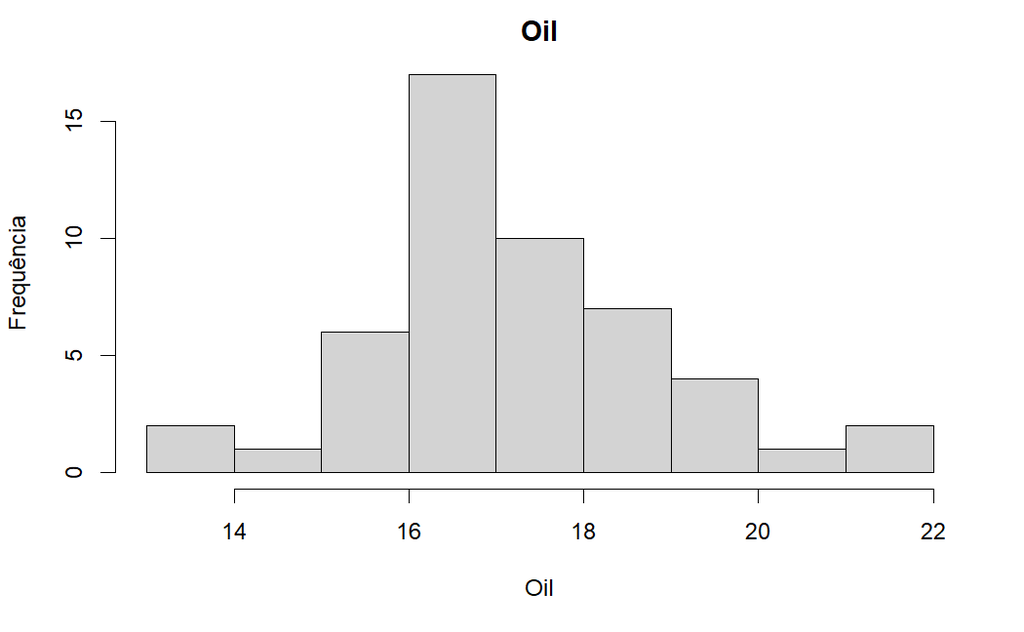

```r
hist(dt$Oil, main = "Oil", xlab = "Oil", ylab="Frequência")
```

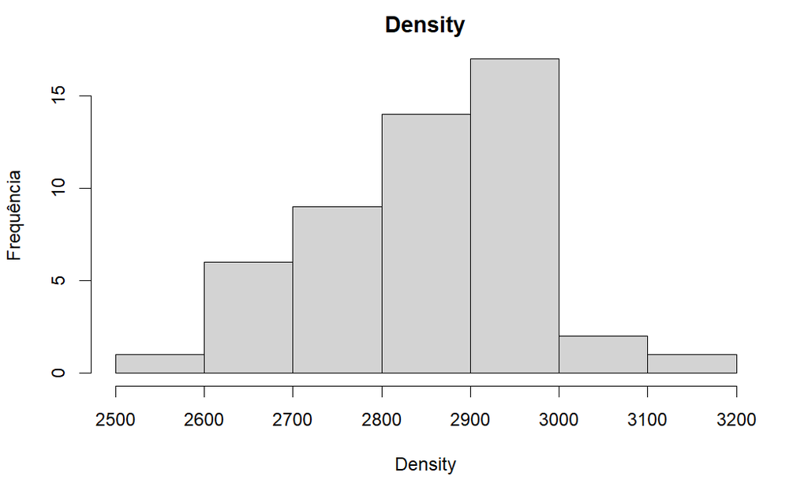

```r
hist(dt$Density, main = "Density", xlab = "Density", ylab="Frequência")
```

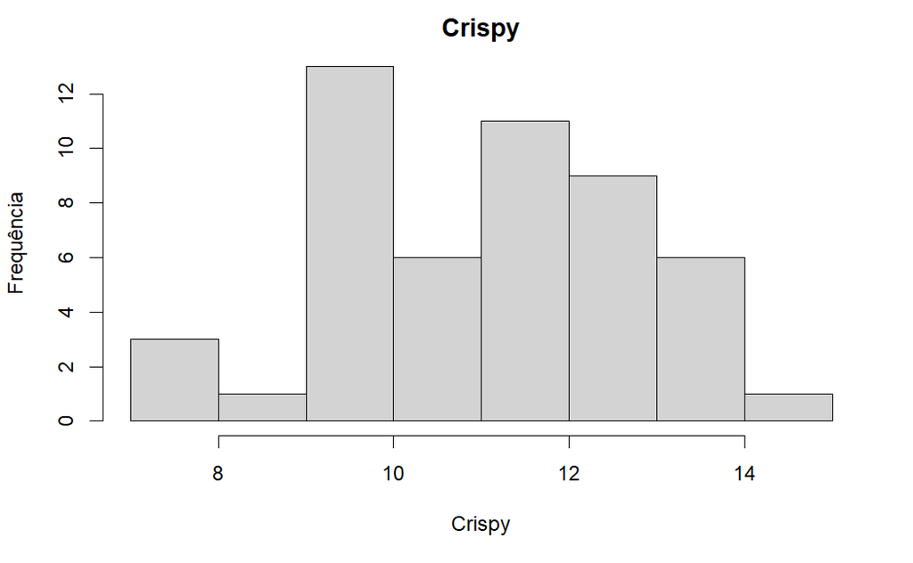

```r
hist(dt$Crispy, main="Crispy", xlab = "Crispy", ylab="Frequência")
```

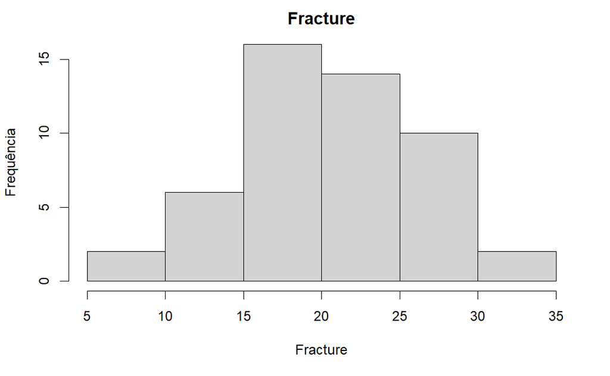

```r
hist(dt$Fracture, main="Fracture", xlab = "Fracture", ylab="Frequência")
```

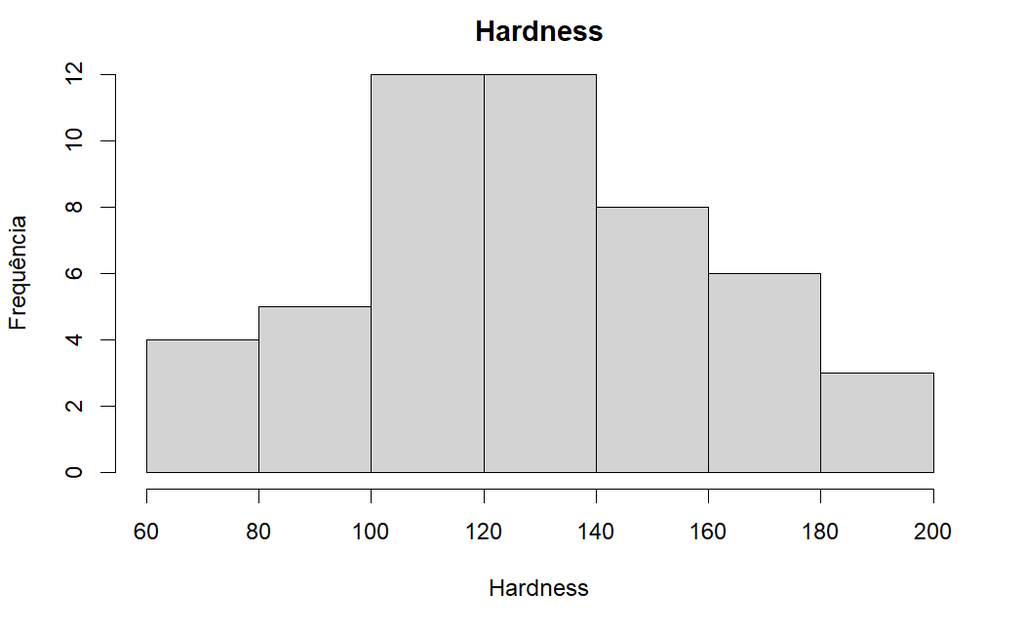

```r
hist(dt$Hardness, main="Hardness", xlab = "Hardness", ylab="Frequência")
```

Os histogramas mostram a distruibuição dos dados. Abaixo serão apresentados testes de normalidade.

```r
shapiro.test(dt$Oil)
```

```
    Shapiro-Wilk normality test

data:  dt$Oil
W = 0.96806, p-value = 0.1927
```

```r
shapiro.test(dt$Density)
```

```
    Shapiro-Wilk normality test

data:  dt$Density
W = 0.98285, p-value = 0.6765
```

```r
shapiro.test(dt$Crispy)
```

```
    Shapiro-Wilk normality test

data:  dt$Crispy
W = 0.94892, p-value = 0.03081
```

```r
shapiro.test(dt$Fracture)
```

```
    Shapiro-Wilk normality test

data:  dt$Fracture
W = 0.98727, p-value = 0.8632
```

```r
shapiro.test(dt$Hardness)
```

```
    Shapiro-Wilk normality test

data:  dt$Hardness
W = 0.98084, p-value = 0.5878
```

Apenas a variável Crispy não passou no teste de normalidade ao nível de significância de 0,05.

De acordo com Hair, as seguintes suposições para as variáveis sob estudo seriam necessárias para a análise fatorial:

- Normalidade
- Homocedasticidade
- Linearidade
- Multicolinearidade

Ainda segundo o autor,

*“de um ponto de vista estatístico, os desvios da normalidade, da homocedasticidade e da linearidade aplicam-se apenas porque eles diminuem as correlações observadas. Apenas a normalidade é necessária se um teste estatístico é aplicado para a significância dos fatores, mas esses testes raramente são usados. Na verdade, um pouco de multicolinearidade é desejável, pois o objetivo é identificar conjuntos de variáveis inter-relacionadas.”*

Desse modo, em termos de verificação das suposições, esse trabalho terá como foco a verificação de medidas gerais de intercorrelação entre as variáveis, apresentada na análise a seguir.

```r
library(Hmisc)
rcorr(as.matrix(dt2))
```

```
           Oil Density Crispy Fracture Hardness
Oil       1.00   -0.75   0.59    -0.53    -0.10
Density  -0.75    1.00  -0.67     0.57     0.11
Crispy    0.59   -0.67   1.00    -0.84     0.41
Fracture -0.53    0.57  -0.84     1.00    -0.37
Hardness -0.10    0.11   0.41    -0.37     1.00

n= 50


P
         Oil    Density Crispy Fracture Hardness
Oil             0.0000  0.0000 0.0000   0.5070
Density  0.0000         0.0000 0.0000   0.4556
Crispy   0.0000 0.0000         0.0000   0.0030
Fracture 0.0000 0.0000  0.0000          0.0076
Hardness 0.5070 0.4556  0.0030 0.0076
```

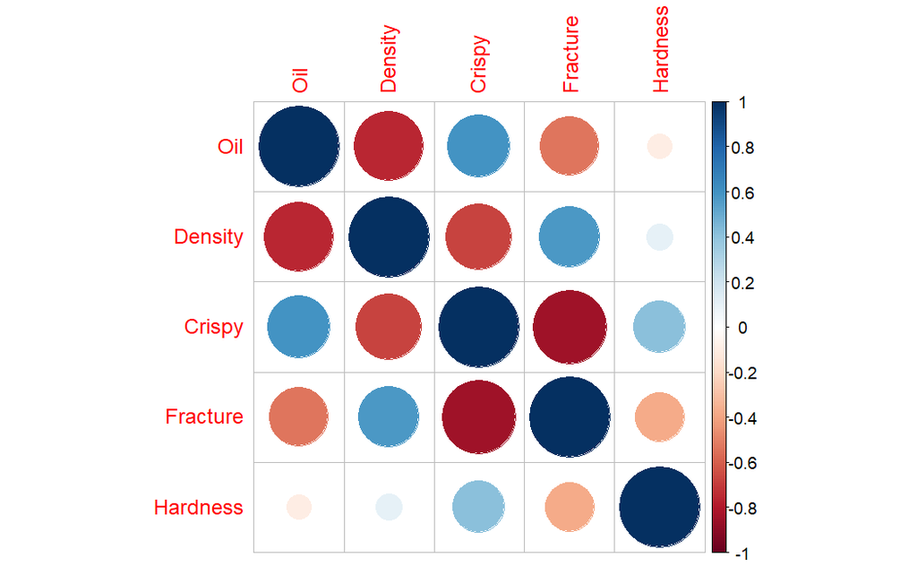

```r
library(corrplot)
corrplot(cor(dt2))
```

A matriz de correlação de Pearson entre as variáveis consideradas (e seus respectivos p-valores) mostra que todas as variáveis têm correlação significativa com pelo menos outra. Grande parte das correlações são maiores (em módulo) do que 0.3, valor considerado como referência por Hair para que a análise fatorial seja apropriada.

Essa **multicolinearidade** observada é desejável (uma vez que nosso objetivo é realizar uma análise fatorial), pois ela garante que as variáveis são suficientemente correlacionadas umas com as outras para produzir fatores representativos.

A fim de determinar, de modo mais objetivo, a adequação da análise fatorial examinando-se a matriz de correlação inteira, é apresentado a seguir o teste de esfericidade de Bartlett:

```r
library(psych)
cortest.bartlett(dt2)
```

```
R was not square, finding R from data
```

```
$chisq
[1] 154.9936

$p.value
[1] 0.0000000000000000000000000003492964

$df
[1] 10
```

No teste de Bartlett, a estatística de teste é utilizada para examinar a hipótese de que as variáveis não sejam correlacionadas na população. Para os dados considerados, a hipótese nula de que a matriz de correlação da população seja uma matriz identidade é rejeitada por esse teste. A estatística qui-quadrado aproximada é 154.9936, com 10 graus de liberdade, significativa ao nível de 0.05 (p-valor<0,0001).

Além do teste de Bartlett, a correlação entre as variáveis pode ser avaliada de modo mais preciso por meio da medida de adequação da amostra (MSA). De acordo com a literatura, valores de MSA devem exceder 0.5 tanto para o teste geral quanto para cada variável individual. Variáveis com MSA < 0.5 devem ser omitidas da análise fatorial uma por vez, sendo aquela com menor valor eliminada a cada vez.

```r
KMO(dt2)
```

```
Kaiser-Meyer-Olkin factor adequacy
Call: KMO(r = dt2)
Overall MSA =  0.71
MSA for each item =
     Oil  Density   Crispy Fracture Hardness
    0.82     0.71     0.67     0.79     0.43
```

No R, a MSA é calculada por meio da **Kaiser-Meyer-Olkin Measure of Sampling Adequacy (KMO)**. O valor de KMO geral é de 0.71, e tem-se também os valores individuais para cada item, os quais, para as cinco variáveis consideradas, variaram entre 0.43 (para Hardness) e 0.82 (para Oil).

O KMO de todas as variáveis excedeu a referência de 0.5, exceto para Hardness. Embora tenha ficado abaixo desse limiar, a variável Harness (assim como as demais) será considerada na análise fatorial, por seu valor ter ficado próximo (embora ligeiramente abaixo) dessa referência. Desse modo, será dado seguimento ao estudo, por meio da Análise Fatorial.

# 4 Análise Fatorial

## 4.1 Determinando número de fatores

O dataset possui apenas 5 variáveis. Abaixo alguns testes para descobrir o mínimo de fatores necessários para a análise.

Teste para 1 fator:

```r
fa=factanal(dt2, factors = 1, method ="mle")
fa
```

```
Call:
factanal(x = dt2, factors = 1, method = "mle")

Uniquenesses:
     Oil  Density   Crispy Fracture Hardness
   0.616    0.524    0.045    0.255    0.850

Loadings:
         Factor1
Oil       0.620
Density  -0.690
Crispy    0.977
Fracture -0.863
Hardness  0.388

               Factor1
SS loadings      2.710
Proportion Var   0.542

Test of the hypothesis that 1 factor is sufficient.
The chi square statistic is 39.57 on 5 degrees of freedom.
The p-value is 0.000000182
```

P-Valor baixo, rejeita-se a hipotese de nula de que 1 fator é suficiente.

Teste para 2 fatores:

```r
fa=factanal(dt2, factors = 2, method ="mle")
fa
```

```
Call:
factanal(x = dt2, factors = 2, method = "mle")

Uniquenesses:
     Oil  Density   Crispy Fracture Hardness
   0.334    0.156    0.042    0.256    0.407

Loadings:
         Factor1 Factor2
Oil      -0.816
Density   0.919
Crispy   -0.745   0.635
Fracture  0.645  -0.573
Hardness          0.764

               Factor1 Factor2
SS loadings      2.490   1.316
Proportion Var   0.498   0.263
Cumulative Var   0.498   0.761

Test of the hypothesis that 2 factors are sufficient.
The chi square statistic is 0.27 on 1 degree of freedom.
The p-value is 0.603
```

Não rejeita-se a hipótese de que 2 fatores sejam suficientes, portanto segue-se a análise com 2 fatores.

## 4.2 Unicidades

Como é possível observar algumas variáveis possuem um ruído bem alto. As medidas abaixo representam a proporção da variabilidade, em cada variável, que não é explicada pela combinação linear dos fatores.

```r
knitr::kable(t(fa$uniquenesses))%>% kable_styling(position = "center")
```

| Oil | Density | Crispy | Fracture | Hardness |
| --- | --- | --- | --- | --- |
| 0.3338599 | 0.1555255 | 0.0422238 | 0.2560235 | 0.4069459 |

```r
#tabela6<- data.frame(fa$uniquenesses)
#colnames(tabela6)<-c("Uniqueness")
#knitr::kable(t(tabela6))%>% kable_styling(position = "center")
```

## 4.3 Cargas

Contribuição das variáveis originais para os fatores. Como é possível observar o Fator 1 tem alta contribuição negativa das variáveis Oil e Crispy. E alta contribuição positiva das variáveis Density e Fracture. Um especialista com essas informações certamente conseguiria uma boa interpretação para a variável latente. Já o Fator 2 possuem grande contribuição possitiva de Crispy e Hardness, e contribuição negativa de Fracture. Os valores faltantes são baixos e portanto desprezados.

```r
fa$loadings
```

```
Loadings:
         Factor1 Factor2
Oil      -0.816
Density   0.919
Crispy   -0.745   0.635
Fracture  0.645  -0.573
Hardness          0.764

               Factor1 Factor2
SS loadings      2.490   1.316
Proportion Var   0.498   0.263
Cumulative Var   0.498   0.761
```

## 4.4 Comunalidade

Fração da variância total explicada pelos fatores, quanto maior, melhor.

```r
apply(fa$loadings^2,1,sum)
```

```
      Oil   Density    Crispy  Fracture  Hardness
0.6661398 0.8444745 0.9577762 0.7439766 0.5930539
```

## 4.5 Proportion Var, Cumulative var e SS Loadings

Proportion var é a variância explicada por cada fator. Cumulative var é o valor acumulado da variância explicada. SS Loadings é a soma das cargas ao quadrado, pela regra de Kaiser devemos manter fatores com SS Loadings > 1.

```r
fa$loadings
```

```
Loadings:
         Factor1 Factor2
Oil      -0.816
Density   0.919
Crispy   -0.745   0.635
Fracture  0.645  -0.573
Hardness          0.764

               Factor1 Factor2
SS loadings      2.490   1.316
Proportion Var   0.498   0.263
Cumulative Var   0.498   0.761
```

## 4.6 Scree Plot

Corrobora a utilização de 2 fatores. O segundo fator é o último antes do ponto de inflexão (linha tracejada).

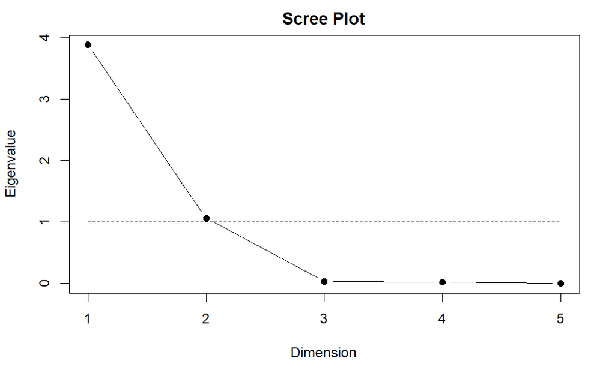

```r
psy::scree.plot(fa$correlation)
```

## 4.7 Estimação Escores

```r
scores = factanal(dt2, factors = 2, method = "mle",scores = "regression")$scores
dt3= data.frame(dt$X,scores)
dt3
```

| dt.X | Factor1 | Factor2 |
| --- | --- | --- |
| B110 | 0.608178929 | -0.60485652 |
| B136 | -1.338353417 | 0.74121570 |
| B171 | 0.151444128 | 0.63655719 |
| B192 | 0.483042701 | -0.97998211 |
| B225 | 0.807737088 | 0.33673197 |
| B237 | -0.496972297 | 0.90014287 |
| B261 | -0.964238242 | 0.09473458 |
| B264 | -0.444141704 | -1.84403591 |
| B353 | 0.676955420 | 0.21726360 |
| B360 | 0.598589966 | 0.15208902 |

[output cut: 40 more lines]

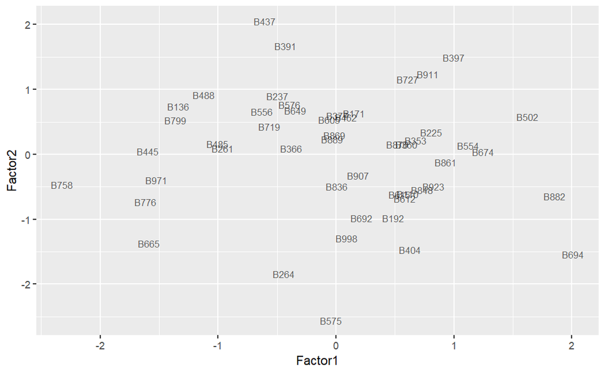

```r
ggplot(dt3, aes(x=Factor1, y=Factor2)) + geom_text(alpha=.6, size=3, aes(label=dt.X))
```

# 5 Conclusão